# 1. 모형진단이란?

: 여러 후보 모형 중 가장 좋은 모형을 선택하기 위한 성능비교.

### 모형진단과정

과대적합/과소적합 여부 구별  
$\rightarrow$ 과대적합이면 표분수를 늘림 or 초모수 조정 or 규제화 / 과소적합이면 특성변수 늘리거나 다른 모형 선택  
$\rightarrow$ 학습데이터로 모형 학습  
$\rightarrow$ 검증데이터에 적용해 최적의 초모수 선택  
$\rightarrow$ 모형의 성능을 비교, 완전히 새로운 시험 데이터의 정밀도로 성능 비교

- 과대적합이란?
- 과소적합이란?

머신러닝의 학습은 학습데이터의 손실함수를 최소화함. 따라서 과대적합이 발생하는게 일반적이며, 과대적합의 해결이 머신러닝의 핵심 문제. 여기서는 과대적합 문제를 다룸.

### 전통적인 통계학 vs 머신러닝

- 전통적인 통계학  
  : 데이터를 구분하지 않고, 전체 데이터를 사용하여 모형을 적합하고, 모형의 적합도를 전체 데이터로부터 구하여서 모형 비교. 추정된 모수에 대해 유의성 검정을 하여 유의하지 않은 모수에 대응하는 특성변수 제거(변수선택). 예측치의 신뢰구간 구함  
  $\rightarrow$ 수리통계적, 확률론적 지식 요구
- 머신러닝  
  : 데이터를 세개로 구분하여(학습/검증/시험 데이터) 정밀도나 손실함수 값을 단순하게 비교한다.  
  $\rightarrow$ 수리통계적, 확률론적 지식을 요구하지 않음.

### 평균모형

평균모형이란, 모든 예측치를 평균 ybar로 대입하는 모형을 말한다.  
특성변수를 전혀 사용하지 않은 모형(평균모형)보다는 기본적으로 성능이 우수해야 한다. 학습데이터와 시험데이터 모두에서 평균모형보다는 성능이 우수해야(손실함수가 더 작아야) 한다.

학습 데이터로 모형 학습(1차적으로 모수추정) 후 검증데이터로 초모수 조절. 학습 데이터의 성능을 원하는 수준으로 유지하되 검증데이터의 성능도 학습데이터에 근접한 수준으로 초모수 조절.  
즉, 여러 개의 초모수 값을 순차적으로 학습데이터와 검증데이터에 적용하여, 검증데이터의 성능이 학습데이터의 성능에 근접하게 하는 초모수를 선택한다.  
이때 학습데이터, 검증데이터, 시험 데이터로 분할한 걸 고정하면, 모형이 선택된 검증데이터에 크게 의존하는 치명적인 약점을 가진다.  
이 약점을 보완하기 위해 나온게 k-분할 교차검증

# 2. K-fold 교차검증

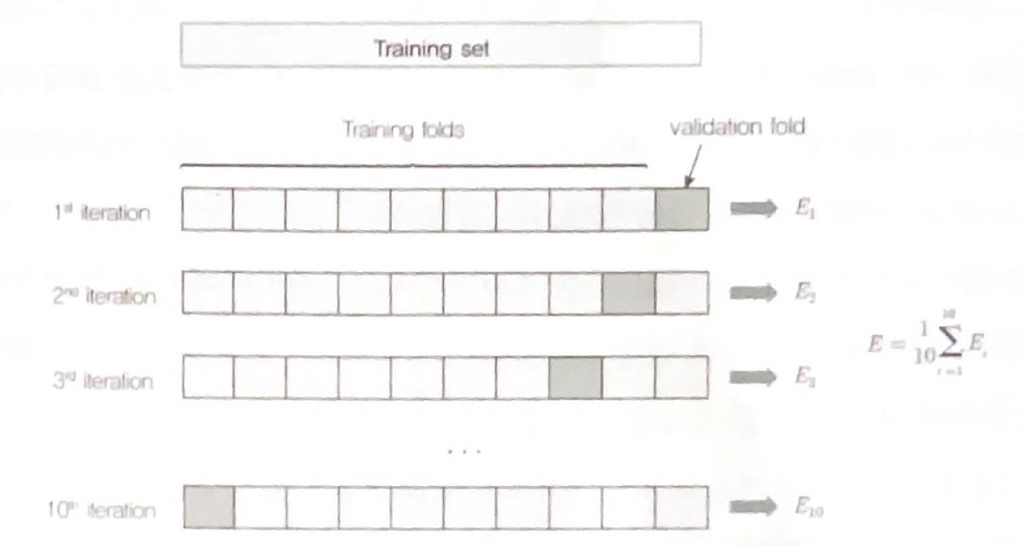

```python
from IPython.display import Image
image_path = 'C:/Users/MijinJ/OneDrive - 경북대학교/바탕 화면/jupyter사진/CV1.jpg'
Image(filename=image_path, width=600)
```

### 10-fold 교차검증

- 1. 전체 데이터를 학습데이터(A) + 시험데이터(B)로 나눔.
- 1. 학습데이터를 k개의 fold로 나눔. 10개의 fold중 k-1개를 학습데이터, 1개를 검증데이터로 사용. 각 분할을 차례대로 검증데이터로 할당하면 k번의 서로 다른 검증데이터가 만들어짐
- 1. 하나의 초모수 값에 대해 k번의 검증 데이터 성능측정 가능. k개의 검증데이터의 성능을 구하고 이들의 평균치를 해당 초모수의 성능으로 평가.
- 1. 3번의 과정을 다른 초모수들로도 한다. 이 중 가장 우수한 검증성능을 가진 초모수를 모형의 초모수로 선택한다.

     > *성능은 보통 손실함수 값으로 측정. 하지만 분석목적이 분류라면 정밀도나 f1 score를 더 많이 사용* 보통 k로 10을 사용하나, 자료가 아주 크면 k=5로 사용한다.  
     > *자료가 매우 적은 경우에는 k=(자료의 개수)로 두는 검증데이터가 하나인 교차검증을 함.  
     > (자료가 20개면 19개를 학습데이터, 1개를 검증데이터로 두며 20개의 자료분할을 하는 것)
- 1. 선택된 초모수로 전체 학습데이터(A)로 모형의 모수를 다시 추정함(표본의 개수가 많을수록 모수 추정의 정밀도가 높아지므로). 학습데이터에서와 시험데이터에서 정밀도가 근사하면 이 모형에 대해 일반화가 완성된 것이다. 일반화가 되지 않는다면 모형에 특성변수를 추가하거나 초모수를 다시 조절한다.

k분할 교차검증(k-fold CV)로 과대적합/과소적합을 미리 진단할 수 있다.

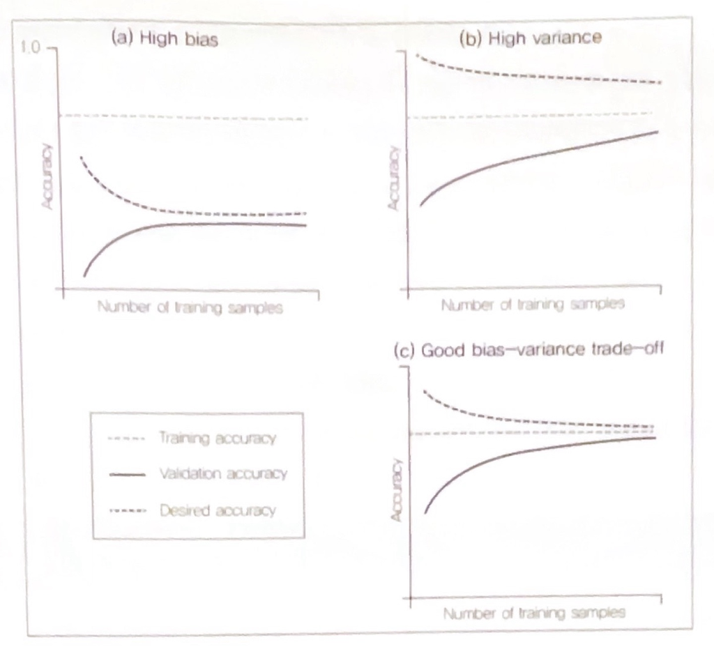

```python
from IPython.display import Image
image_path = 'C:/Users/MijinJ/OneDrive - 경북대학교/바탕 화면/jupyter사진/CV2.jpg'
Image(filename=image_path, width=500)
```

# 실습1 pipeline의 사용

실습데이터: 유방암 환자 자료. 유방암환자(M)과 정상인(B)의 2개 클래스와 30개 특성변수(세포핵의 디지털 이미지)로 구성됨

scikit learn의 pipeline 명령어: 차원축소 후 모형적용까지를 쉽게 해결가능

```python
import pandas as pd
#유방암 자료.
df=pd.read_csv('https://archive.ics.uci.edu/ml/machine-learning-databases''/breast-cancer-wisconsin/wdbc.data', header=None)

from sklearn.preprocessing import LabelEncoder
y=df.loc[:,1].values   #유방암환자(M)과 정상인(B)의 2개의 클래스를 가지는 y
X=df.loc[:,2:].values  #30개 특성자료를 X에 할당. 30개의 특성자료는 세포핵의 디지털 이미지 자료

#목적변수의 클래스 M과 B를 0과 1로 전환하는 label encoding
le=LabelEncoder()
y=le.fit_transform(y)   #y의 class [B,M]을 class [0,1]로 전환
le.classes_
```

```
array(['B', 'M'], dtype=object)
```

```python
print(1-y.mean())
```

```
0.6274165202108963
```

y를 무조건 0으로만 분류해도(평균모형) 약 63%의 정밀도를 가진다는 뜻.  
따라서 모형의 성능이 최소한 0.63이상이 되어야 모형의 기능을 함

```python
#학습데이터와 시험데이터 분할
from sklearn.model_selection import train_test_split
X_train, X_test, y_train, y_test = train_test_split(X,y,test_size=0.20, stratify=y, random_state=1)
```

make_pipeline() 함수에 사용하고자하는 모든 자료변환을 적용 순서대로 나열한 후, 최종 학습 모형을 지정해주면 된다.

```python
#pipeline
from sklearn.preprocessing import StandardScaler
from sklearn.decomposition import PCA
from sklearn.linear_model import LogisticRegression
from sklearn.pipeline import make_pipeline

#표준화->PCA->LogisticRegression 순서로 적용하는 pipeline 객체화
pipe_lr=make_pipeline(StandardScaler(), PCA(n_components=4), LogisticRegression(random_state=1))

pipe_lr.fit(X_train, y_train)          #pipeline과정에 학습데이터로 학습
y_train_pred=pipe_lr.predict(X_train)  #학습한 모델이 학습데이터 X에 대해 y를 예측한 결과
y_test_pred=pipe_lr.predict(X_test)    #한습한 모델이 시험데이터 X에 대해 y를 예측한 결과
```

#### pipe_lr.fit(X_train, y_train)

표준화 fit -> 표준화 transformation -> PCA fit -> PCA transformation -> LogisticRegression fit 순서로 traning data 처리

#### pipe_lr.predict(X_train), pipe_lr.predict(X_test)

표준화 transformation -> PCA transformation -> LogisticRegression prediction 순서로 traning data, test data 처리

```python
#Accuracy score
pipe_lr.score(X_train, y_train)
```

```
0.967032967032967
```

```python
pipe_lr.score(X_test,y_test)
```

```
0.956140350877193
```

# 실습2 pipeline을 이용한 k-분할 교차검증

stratified k-fold cross-validation : 각 분할의 클래스 비율이 전체 클래스 비율과 동일하게 하는 층화 k-분할 교차검증  
cross-validation의 목적은 초모수의 결정

### 간단한 작동 원리

```python
from sklearn.model_selection import cross_val_score
scores=cross_val_score(estimator=pipe_lr, X=X_train, y=y_train, cv=10)   #10개의 분할(k=10)로 구성된 교차검증
print('CV accuracy scores: %s' % scores)   #10개의 검증데이터로 구한 10개의 정밀도
```

[output not shown]

```python
import numpy as np
print('CV accuracy: %.3f +/- %.3f' % (np.mean(scores), np.std(scores)))   #10개의 검증데이터로 구한 정밀도의 평균/표준편차
```

```
CV accuracy: 0.965 +/- 0.022
```

### 과대적합/과소적합 판단

```python
import numpy as np
import matplotlib.pyplot as plt
from sklearn.model_selection import learning_curve
pipe_lr=make_pipeline(StandardScaler(), LogisticRegression(penalty='l2', random_state=1))
train_sizes, train_scores, test_scores=\
                    learning_curve(estimator=pipe_lr, X=X_train, y=y_train,
                                train_sizes=np.linspace(0.1, 1.0, 10), cv=10)   #학습데이터 크기에 따른 모형의 성능 파악
train_mean=np.mean(train_scores, axis=1)
train_std=np.std(train_scores, axis=1)
test_mean=np.mean(test_scores, axis=1)
test_std=np.std(test_scores, axis=1)
```

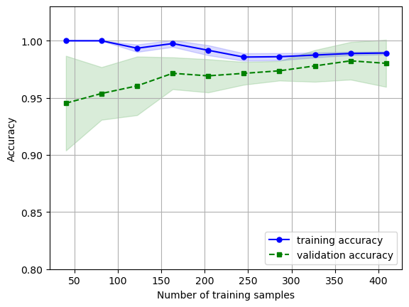

```python
plt.plot(train_sizes, train_mean, color='blue', marker='o', markersize=5, label='training accuracy')
plt.fill_between(train_sizes, train_mean+train_std, train_mean-train_std, alpha=0.15, color='blue')

plt.plot(train_sizes, test_mean, color='green', linestyle='--', marker='s', markersize=5, label='validation accuracy')
plt.fill_between(train_sizes, test_mean+test_std, test_mean-test_std, alpha=0.15, color='green')

plt.grid()
plt.xlabel('Number of training samples')
plt.ylabel('Accuracy')
plt.legend(loc='lower right')
plt.ylim([0.8, 1.03])
plt.show()
```

과대적합 및 과소적합 문제가 발생하지 않은 모형으로 볼 수 있음

### pipeline을 이용한 초모수의 결정 : GridSearchCV()

get_params().keys() : 해당 모형에 있는 초모수에는 어떤 것들이 있는지 출력해주는 역할

```python
from sklearn.svm import SVC
model=SVC()
print(model.get_params().keys())  #모형의 모수에 대한 key파악
from sklearn.tree import DecisionTreeClassifier
DecisionTreeClassifier().get_params().keys()
```

```
dict_keys(['C', 'break_ties', 'cache_size', 'class_weight', 'coef0', 'decision_function_shape', 'degree', 'gamma', 'kernel', 'max_iter', 'probability', 'random_state', 'shrinking', 'tol', 'verbose'])
```

```
dict_keys(['ccp_alpha', 'class_weight', 'criterion', 'max_depth', 'max_features', 'max_leaf_nodes', 'min_impurity_decrease', 'min_samples_leaf', 'min_samples_split', 'min_weight_fraction_leaf', 'random_state', 'splitter'])
```

최상의 초모수를 구하기 위한 GridSearchCV()함수  
make_pipeline에서 2개 이상의 모형을 사용하므로 GridSearchCV()의 param_grid에 모형의 key를 그대로 사용하지 못함.

GridSearchCV()를 이용해 SVM의 선형모형/커널 SVM 중 어떤걸 사용할지, 각 경우에서 초모수 C가 어떤 값일 때 검증데이터의 accuracy가 최대가 될지를 결정.  
grid search를 10-분할 교차검증을 사용하여 param_range와 param_grid에 지정된 값 중에서 찾아내고 있다.

```python
from sklearn.model_selection import GridSearchCV
from sklearn.svm import SVC

pipe_svc=make_pipeline(StandardScaler(), SVC(random_state=1))
param_range=[0.0001, 0.001, 0.01, 0.1, 1.0, 10.0, 100.0, 1000.0]
param_grid=[{'svc__C':param_range, 'svc__kernel':['linear']},
           {'svc__C':param_range, 'svc__gamma':param_range, 'svc__kernel': ['rbf']}]
gs=GridSearchCV(estimator=pipe_svc, param_grid=param_grid, scoring='accuracy', cv=10)
gs=gs.fit(X_train, y_train)
print(gs.best_score_)
```

```
0.9846859903381642
```

```python
print(gs.best_params_)
```

```
{'svc__C': 100.0, 'svc__gamma': 0.001, 'svc__kernel': 'rbf'}
```

C=100, 커널은 방사형기저함수, $\gamma$는 0.001의 비선형 커널 SVM일때 검증데이터의 accuracy가 가장 높다는 결론